# Run the cell below to generate the road map (do not modify it)

#### Question 20

Since in the usecase we build and test the model from the same data, it can lead to overfitting problems. To avoid that, we can divide the data into training set and testing set. Note that each neuron occurs only one time in the data. So, we can not divide the data by dividing the neurons. Instead, we can divide the states of neurons into two different sets. Let's try with this approach and show the result.

```python
def rand_bools_func(n):
    t = [True]*n + [False]*(20-n)
    return t

def build_new_vector(l,booleans,reverse):
    out = []
    for i in range(len(booleans)):
        if booleans[i]^reverse:
            out.append(l[i])
    return out

# first we split the data. 50% training and 50% test.
data_choice = data.tordd().map(lambda x : (x[1],rand_bools_func(10))).cache()
test_data = np.array(data_choice.map(lambda x : build_new_vector(x[0],x[1],False)).collect()).reshape(2,76,87,10)
training_data = np.array(data_choice.map(lambda x : build_new_vector(x[0],x[1],True)).collect()).reshape(2,76,87,10)
test_data = td.series.fromlist(test_data, npartitions=6).toimages().tospark(sc).toseries()
training_data = td.series.fromlist(training_data, npartitions=6).toimages().tospark(sc).toseries()
```

There is an error in the source code of thunder.

AttributeError: 'Series' object has no attribute 'lables'

it should have been 'labels'. We can't use Spark directly on series. We need to use images then apply toseries()

```
Series
mode: spark
dtype: float64
shape: (2, 76, 87, 10)
```

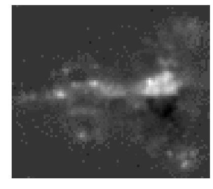

```python
# Just checking if the data is ok
print(test_data)
draw_image(test_data[0,:,:,0])
```

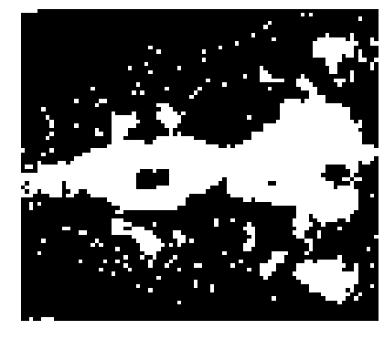

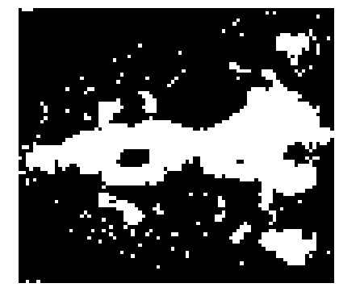

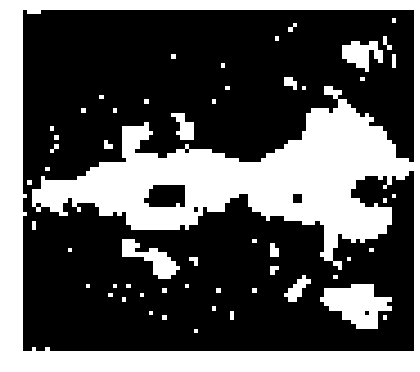

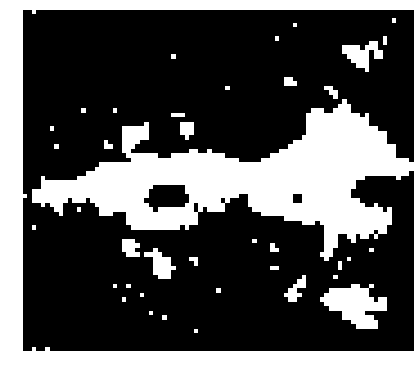

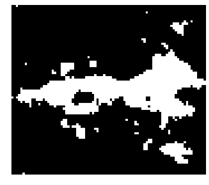

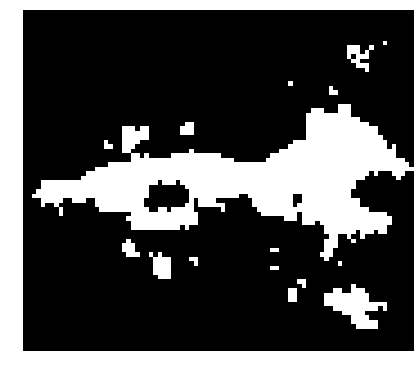

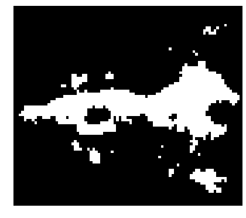

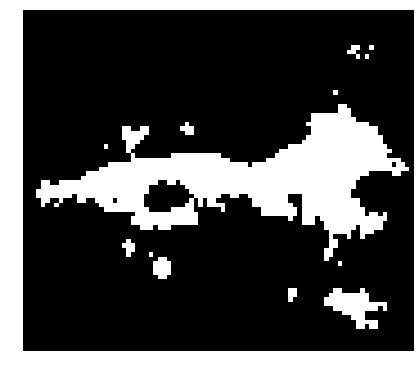

[figure not shown]

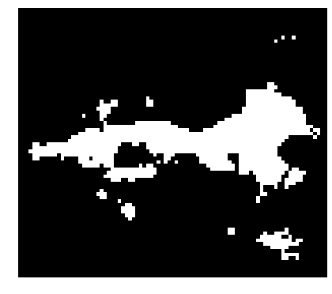

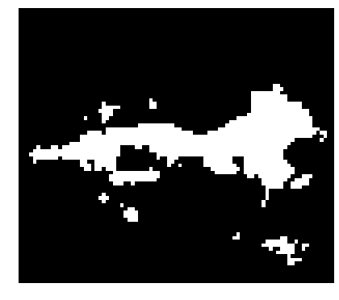

```python
# We need to recompute the threshold using only the training_data this time.
stdMap = training_data.map(lambda x: x.std()).toarray()
for threshold in np.arange(0.015,0.025,0.001):
    draw_image(stdMap[0,:,:] > threshold)
```

```python
threshold = 0.02
# remove series object that has the standard deviation bigger than a threshold
filtered = training_data.filter(lambda x : x.std() < threshold)
filtered_rdd = filtered.tordd().map(lambda x: np.array(x[1]))
```

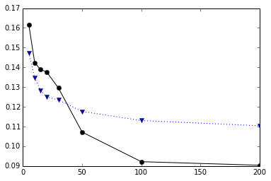

```python
# now we can built the models with the relevant training data.
models = buildModels(filtered_rdd)
testAndPlotTheResult(training_data, models)
```

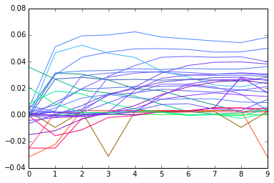

```python
# creating the colors for the final plot.
bestModel = models[4]
newClrs = optimize_color(bestModel.centers)
plt.gca().set_color_cycle(newClrs.colors)
plt.plot(np.array(bestModel.centers).T)
```

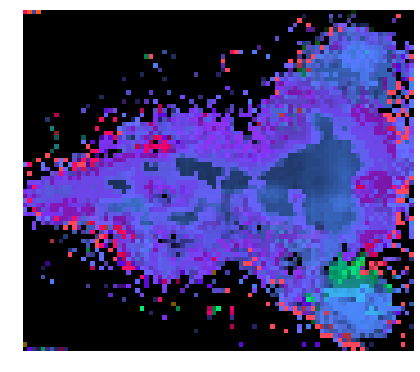

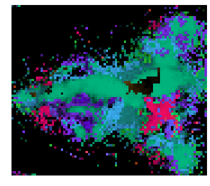

```python
def show_results(data):
    # predict the nearest cluster id for each voxel in Series
    labels = data.map(lambda x : bestModel.predict(x))# to check

    # collect data to the driver
    imgLabels = labels.toarray() # to check

    sim = data.map(lambda x: similarity(bestModel.centers, x))

    imgSim = sim.toarray()

    # draw image with the new color scheme
    brainmap = transform(newClrs, imgLabels[0,:,:], mask=imgSim[0,:,:])
    return brainmap

draw_image(show_results(training_data))
draw_image(show_results(test_data))
```

[figure not shown]

#### Question 21

Is using K-Means the best choice for a clustering algorithm? Comment the choice and suggest alternatives. For example, look at [Mixture Models](https://en.wikipedia.org/wiki/Mixture_model) and, if you have time, propose an alternative clustering technique.

**NOTE**: Mixture models will be covered in the ASI course in greater detail.

K-Means can't separate correctly two clusters which have different sizes. Here's a simple example :

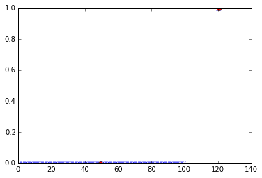

```python
#lets create a list to show how inaccurate K-mean will be on a simple example
liste = np.transpose([[i,0] for i in range(100)] + [[120,1],[121,1]])
plt.plot(liste[0], liste[1], 'x')
plt.plot([49.5, 120.5],[0,1],'ro')
plt.plot([85,85],[0,1],'g-')
```

The x are the datapoints. the o are the means of the clusters. the green line is where K-means will split the clusters (with K=2).

Let's see a more appropriate clustering method for this Notebook : mixture model.

```python
from sklearn import mixture
g = mixture.GMM(n_components=20)
g.fit(data.flatten().toarray())
labelled_data = g.predict(data.flatten().toarray()).reshape(2,76,87)
```

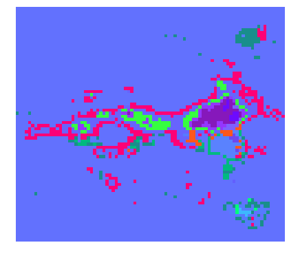

```python
# draw image with the new color scheme
brainmap = transform(newClrs, labelled_data[0,:,:])
draw_image(brainmap)
```

The results are more focused on the important neurons. We may have lost a part of the brain, but all the useless data has been deleted. We can improve the results by choosing the best value of K. This can be easily done as this code runs very quickly. We can also split the data into training and test data to make the results more accurate for new data.

```
[None, None, None, None, None, None, None, None]
```

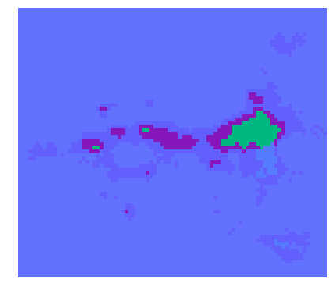

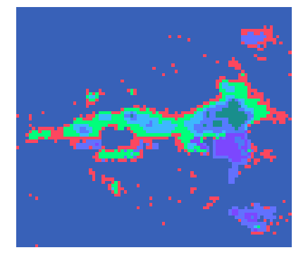

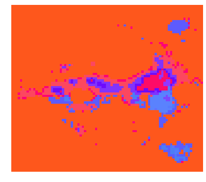

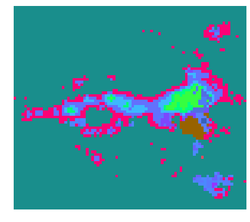

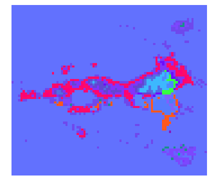

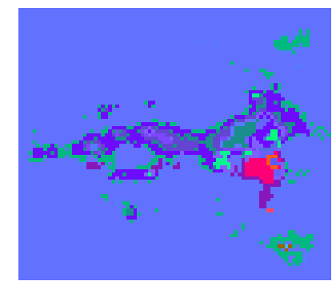

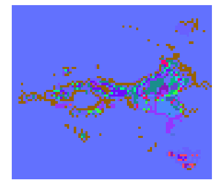

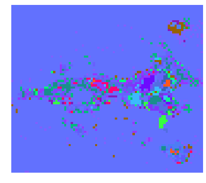

```python
def test_mixture(data,K):
    g = mixture.GMM(n_components=K)
    g.fit(data.flatten().toarray())
    labelled_data = g.predict(data.flatten().toarray()).reshape(2,76,87)
    brainmap = transform(newClrs, labelled_data[0,:,:])
    draw_image(brainmap)

[test_mixture(data,K) for K in ks]
```

for K >= 30, the data is too much separated. K=5 may be a bit too low. But for K from 10 to 20, the brain map seems to be accurate enough.

# References

Some of the examples in this notebook are inspired from the [documentation of Thunder](http://docs.thunder-project.org/).